# Chapter 3: Coding Population Nonlinear Mixed Effects Models

MI-210 Essentials of Population PKPD M&S — Pumas Edition

Author

Adapted from Marc R. Gastonguay, Ph.D. (Metrum Institute)

Published

April 18, 2026

# 1 Overview

This chapter covers coding pharmacometric models in Pumas — the Julia equivalent of coding NONMEM control streams via NMTRAN. Topics include:

- Coding pharmaco-statistical models through the Pumas `@model` macro
- Interpreting modeling output
- The Pumas analytical model library (equivalent to PREDPP)
- Practice problems: enzyme kinetics, QTc, AST, and PopPK

# 2 Coding Pharmaco-Statistical Models in Pumas

## 2.1 NONMEM vs. Pumas Model Structure

In NONMEM, models are specified through control stream records. In Pumas, the `@model` macro provides a structured, block-based equivalent:

| NONMEM Record | Pumas Block | Purpose |
| --- | --- | --- |
| `$PROBLEM` | `@metadata` | Problem description |
| `$INPUT` / `$DATA` | `read_pumas()` | Data specification |
| `$THETA` | `@param` | Fixed effect parameters |
| `$OMEGA` | `@param` + `@random` | Random effect variance |
| `$SIGMA` | `@param` | Residual error parameters |
| `$PK` | `@pre` | Individual parameter definitions |
| `$PRED` | `@pre` + `@derived` | Algebraic model (no dynamics) |
| `$SUBROUTINES` | `@dynamics` | PK model library |
| `$DES` | `@dynamics begin ... end` | User-defined ODEs |
| `$ERROR` | `@derived` | Observation model |
| `$ESTIMATION` | `fit()` | Estimation method |
| `$COVARIANCE` | `infer()` | Standard errors |
| `$TABLE` | `inspect()` | Predictions and residuals |

## 2.2 PRED Model Example (No Dynamics)

The book shows an Emax model coded with `$PRED`. Here is the NONMEM vs. Pumas side-by-side:

**NONMEM**

```
$PROB EMAX MODEL
$INPUT ID DV CONC
$DATA PDDATA.CSV IGNORE=C

$PRED
EMAX=THETA(1)*EXP(ETA(1))
EC50=THETA(2)*EXP(ETA(2))
E=EMAX*CONC/(EC50+CONC)
Y=E + EPS(1)

$THETA (0, 100) (0, 20)   ; EMAX and EC50
$OMEGA 0.4  0.4
$SIGMA 9
$ESTIMATION MAXEVAL=9999 PRINT=10
```

**Pumas**

```julia
emax_model = @model begin
    @param begin
        tvEmax ∈ RealDomain(lower = 0.0, init = 100.0)
        tvEC50 ∈ RealDomain(lower = 0.0, init = 20.0)
        Ω      ∈ PDiagDomain(2)
        σ_add  ∈ RealDomain(lower = 0.0, init = 3.0)  # sqrt(9)
    end
    @random begin
        η ~ MvNormal(Ω)
    end
    @covariates CONC
    @pre begin
        Emax = tvEmax * exp(η[1])
        EC50 = tvEC50 * exp(η[2])
    end
    @derived begin
        mu := @. Emax * CONC / (EC50 + CONC)
        dv ~ @. Normal(mu, σ_add)
    end
end
```

## 2.3 PREDPP Model Example (Compartmental Dynamics)

**Physiological Meaning of PK Parameters**

The one-compartment oral PK model describes a drug that enters a **depot compartment** (representing the gastrointestinal tract), undergoes **first-order absorption** at rate $K_a$ into the systemic circulation (central compartment), and is eliminated by first-order processes governed by clearance ($CL$). The **volume of distribution** ($V$) is not a real physiological volume — it is a proportionality constant relating the total amount of drug in the body to the measured plasma concentration: $V = X / C$. For a 70-kg human, $V$ can far exceed total body water (~42 L) because drug partitions into tissues according to $V = V_P + V_T \cdot f_U / f_{UT}$, where $f_U$ and $f_{UT}$ are the fractions unbound in plasma and tissue, respectively. **Clearance** ($CL$) is the volume of blood irreversibly cleared of drug per unit time (L/hr). It is not itself a rate; rather, it converts an observed concentration into an elimination rate via $\text{Rate} = CL \times C$. For a linear system, $CL = \text{Dose} / \text{AUC}$ and is independent of dose.

The book shows a 1-compartment oral PK model with ADVAN2 TRANS2. In Pumas, `Depots1Central1` is the analytical equivalent:

**NONMEM**

```
$PROB Pop PK model
$INPUT C ID DV AMT II ADDL TIME
$DATA ../data.CSV IGNORE=C
$SUB ADVAN2 TRANS2

$PK
CL=THETA(1)*EXP(ETA(1))
V=THETA(2)*EXP(ETA(2))
KA=THETA(3)*EXP(ETA(3))
S2=V

$ERROR
Y=F*(1+ERR(1))
IPRED=F

$THETA (0, 8) (0, 50) (0, 0.45)
$OMEGA 0.04 0.04 0.04
$SIGMA 0.04
$ESTIMATION MAXEVAL=9999 METHOD=0 POSTHOC
```

**Pumas**

```julia
poppk_model = @model begin
    @param begin
        tvCL ∈ RealDomain(lower = 0.0, init = 8.0)
        tvV  ∈ RealDomain(lower = 0.0, init = 50.0)
        tvKa ∈ RealDomain(lower = 0.0, init = 0.45)
        Ω    ∈ PDiagDomain(3)
        σ_prop ∈ RealDomain(lower = 0.0, init = 0.2)  # sqrt(0.04)
    end
    @random begin
        η ~ MvNormal(Ω)
    end
    @pre begin
        CL = tvCL * exp(η[1])
        Vc = tvV  * exp(η[2])
        Ka = tvKa * exp(η[3])
    end
    @dynamics Depots1Central1
    @derived begin
        cp := @. Central / Vc
        dv ~ @. Normal(cp, abs(cp) * σ_prop)
    end
end
```

## 2.4 The Pumas Analytical Model Library

Pumas provides closed-form analytical solutions equivalent to NONMEM’s PREDPP ADVAN subroutines:

| NONMEM ADVAN | Pumas Dynamics | Description | Required `@pre` |
| --- | --- | --- | --- |
| ADVAN1 | `Central1` | 1-cpt IV | `CL`, `Vc` |
| ADVAN2 | `Depots1Central1` | 1-cpt oral | `CL`, `Vc`, `Ka` |
| ADVAN3 | `Central1Periph1` | 2-cpt IV | `CL`, `Vc`, `Q`, `Vp` |
| ADVAN4 | `Depots1Central1Periph1` | 2-cpt oral | `CL`, `Vc`, `Q`, `Vp`, `Ka` |
| ADVAN11 | `Central1Periph2` | 3-cpt IV | `CL`, `Vc`, `Q2`, `Vp2`, `Q3`, `Vp3` |
| ADVAN12 | `Depots1Central1Periph2` | 3-cpt oral | `CL`, `Vc`, `Q2`, `Vp2`, `Q3`, `Vp3`, `Ka` |
| ADVAN6/13 | `@dynamics begin ... end` | User ODEs | User-defined |

**Choosing the Number of Compartments**

The choice of compartmental model is determined by the shape of the concentration-time curve on a **semi-logarithmic plot**. A **one-compartment model** assumes instantaneous distribution throughout the body, producing a monoexponential decline ($C(t) = C_0 \cdot e^{-Kt}$) that appears as a single straight line on a log-linear plot. A **two-compartment model** produces a **biexponential decline** with a rapid initial $\alpha$ (distribution) phase followed by a slower $\beta$ (elimination) phase — two distinct slopes on the semi-log plot. Adding an oral depot compartment (e.g., `Depots1Central1`, `Depots1Central1Periph1`) introduces a rising absorption phase governed by $K_a$; the depot represents the GI tract where drug undergoes first-order absorption. Zero-order absorption (constant-rate input) is used for sustained-release formulations or IV infusions. Importantly, the “number of compartments” refers only to the systemic distribution compartments — the depot is not counted. Model selection should be guided by the data (graphical assessment of the log-concentration profile), not by physiological plausibility alone.

**Note**

**Key differences from NONMEM:**

- No `S2=V` scaling needed — divide compartment by volume explicitly in `@derived`
- Parameter names are case-sensitive and must match exactly: `CL`, `Vc`, `Ka`, `Q`, `Vp`
- `TRANS2` parameterization (CL, V, KA) maps directly to Pumas analytical models

### 2.4.1 Four Ways to Specify Dynamics in Pumas

Beyond the analytical library, Pumas supports multiple equivalent approaches for specifying model dynamics. All produce identical results for the same model:

**Closed-Form (Analytical)**

Fastest. Use when the model matches a library structure.

```julia
@dynamics Depots1Central1
```

**Explicit ODEs**

Most flexible. Required for nonlinear elimination, indirect response, or any custom dynamics.

```julia
@dynamics begin
    Depot'   = -Ka * Depot
    Central' = Ka * Depot - (CL / Vc) * Central
end
```

Pumas automatically detects linear ODE systems and solves via matrix exponential (faster than numerical integration). Use `@options begin checklinear = false end` to force numerical integration for nonlinear systems.

**ModelingToolkit (Symbolic ODEs)**

Define the ODE symbolically outside the model, enabling structural identifiability analysis and automatic simplification.

```julia
using ModelingToolkit

@mtkmodel MTK1Cpt begin
    @parameters begin
        Ka
        CL
        Vc
    end
    @variables begin
        Depot(t) = 0.0
        Central(t) = 0.0
    end
    @equations begin
        D(Depot)   ~ -Ka * Depot
        D(Central) ~ Ka * Depot - (CL / Vc) * Central
    end
end

@mtkbuild sys = MTK1Cpt()

# Then in your model:
@dynamics sys
```

**Catalyst (Reaction Networks)**

Define dynamics as chemical/pharmacological reactions — intuitive for PBPK, QSP, and TMDD models.

```julia
using Catalyst

rn = @reaction_network begin
    Ka,    Depot --> Central
    CL/Vc, Central --> 0
end

# Then in your model:
@dynamics rn
```

**Which Dynamics Approach to Use?**

- **Analytical (closed-form):** Default choice for standard 1/2/3-compartment models — fastest execution
- **Explicit ODEs:** Nonlinear PK (Michaelis-Menten), indirect response, effect compartment, custom models
- **ModelingToolkit:** When you need symbolic manipulation, identifiability analysis, or model composition
- **Catalyst reactions:** PBPK, QSP, TMDD — large reaction networks where stoichiometry is natural

### 2.4.2 Absorption Model Patterns

Beyond first-order absorption (`Ka` with `Depots1Central1`), Pumas supports a range of absorption models via `@dynamics` and `@dosecontrol`:

| Absorption Type | Implementation | Key Parameters |
| --- | --- | --- |
| First-order | `Depots1Central1` or `Depot' = -Ka * Depot` | `Ka` |
| Zero-order | `@dosecontrol begin duration = (Central = dur,) end` | `dur` (duration) |
| Parallel ZO + FO | Dual virtual doses with `bioav` splitting | `Ka`, `dur`, `Frac` |
| Two parallel FO | Two depot compartments with different Ka | `Ka1`, `Ka2`, `Frac` |
| Transit compartments | Chain: `T1' = -Ktr*T1`; `T2' = Ktr*T1 - Ktr*T2`; … | `Ktr`, `n` |
| Erlang | `@delay(Erlang(N, MAT/N), Central)` | `N` (integer shape), `MAT` |
| Gamma | `@delay(Gamma(N, MAT/N), Central)` | `N` (continuous shape), `MAT` |
| Weibull | `@delay(Weibull(k, λ), Central)` | `k` (shape), `λ` (scale) |

See the [Absorption Models tutorial](https://tutorials.pumas.ai/html/advanced_topics/absorption_models.html) for complete working examples of each.

## 2.5 Interpreting Modeling Output

In Pumas, model output is accessed programmatically rather than parsed from text files:

[output not shown]

**Useful variance terms:**

- For exponential IIV: $\%CV \approx \sqrt{\omega^2} \times 100$
- For additive IIV: $SD = \sqrt{\omega^2}$
- %RSE: $\%RSE = \frac{SE}{PE} \times 100$

# 3 Practice Problems

**Michaelis-Menten Kinetics: The Foundation of Emax and Nonlinear PK**

The Michaelis-Menten equation describes the rate of an enzymatic reaction as a function of substrate concentration:

$$V = \frac{V_{\max} \cdot C}{K_M + C}$$

$V_{\max}$ reflects the **enzyme capacity** — the maximum rate achievable when all enzyme active sites are saturated. $K_M$ is the substrate concentration at which the reaction rate is 50% of $V_{\max}$ and serves as a surrogate for **affinity**: a low $K_M$ indicates high affinity of substrate for enzyme. This equation is structurally identical to the $E_{\max}$ model in pharmacodynamics, where $E_{\max} \leftrightarrow V_{\max}$ and $EC_{50} \leftrightarrow K_M$. At low concentrations ($C \ll K_M$), the equation simplifies to $V \approx (V_{\max}/K_M) \cdot C$, yielding approximately **linear** (first-order) kinetics. At high concentrations ($C \gg K_M$), the rate saturates at $V_{\max}$, producing **zero-order** kinetics. This saturation is the mechanistic basis for **nonlinear (capacity-limited) pharmacokinetics** — drugs such as phenytoin and ethanol exhibit dose-disproportional increases in exposure because their metabolizing enzymes become saturated at therapeutic concentrations.

## 3.1 Problem 1: Enzyme Kinetics (Michaelis-Menten)

Population analysis of in-vitro enzyme activity data in 20 liver slice samples. Concentrations: 0.1, 0.3, 1, 3, 10, 30, 100, 300, 1000 uM.

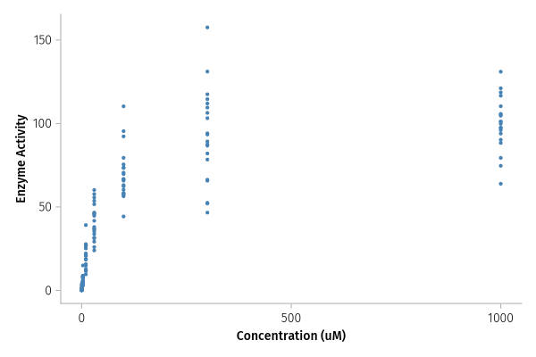

```julia
raw_enz = CSV.read(joinpath(data_dir, "enz3.csv"), DataFrame)

# Fix data entry error (concentration > 1000 → 1000, as in R script)
enz_df = @rtransform(raw_enz,
    :Concentration = :Concentration > 1000 ? 1000.0 : Float64(:Concentration),
)
rename!(enz_df, :ID => :id, :Concentration => :CONC, :ObsActivity => :dv)

fig = Figure(size = (600, 400))
ax = Axis(fig[1, 1], xlabel = "Concentration (uM)", ylabel = "Enzyme Activity")
scatter!(ax, enz_df.CONC, enz_df.dv, color = :steelblue, markersize = 6)
fig
```

```julia
# Use concentration as time axis (non-temporal PRED-style model)
enz_df.time = Float64.(enz_df.CONC)

pop_enz = read_pumas(enz_df; observations = [:dv], covariates = [:CONC], event_data = false)
```

```
Population
  Subjects: 20
  Covariates: CONC
  Observations: dv
```

```julia
enz_model = @model begin
    @metadata begin
        desc = "Michaelis-Menten Enzyme Kinetics"
    end
    @param begin
        tvKM   ∈ RealDomain(lower = 0.0, init = 20.0)
        tvVMAX ∈ RealDomain(lower = 0.0, init = 120.0)
        Ω      ∈ PDiagDomain(2)
        σ_add  ∈ RealDomain(lower = 0.0, init = 3.16)
    end
    @random begin
        η ~ MvNormal(Ω)
    end
    @covariates CONC
    @pre begin
        KM   = tvKM * exp(η[1])
        VMAX = tvVMAX * exp(η[2])
    end
    @derived begin
        ACT := @. VMAX * CONC / (KM + CONC)
        dv ~ @. Normal(ACT, σ_add)
    end
end
```

```
PumasModel
  Parameters: tvKM, tvVMAX, Ω, σ_add
  Random effects: η
  Covariates: CONC
  Dynamical system variables:
  Dynamical system type: No dynamical model
  Derived: dv
  Observed: dv
```

```julia
enz_params = (tvKM = 20.0, tvVMAX = 120.0, Ω = Diagonal([0.04, 0.04]), σ_add = sqrt(10.0))

# FO estimation (METHOD=0)
enz_fo = fit(enz_model, pop_enz, enz_params, Pumas.FO())
enz_fo
```

```
[ Info: Checking the initial parameter values.
[ Info: The initial negative log likelihood and its gradient are finite. Check passed.
Iter     Function value   Gradient norm
     0     1.612324e+03     2.021640e+03
 * time: 0.012627124786376953
     1     7.765242e+02     1.665303e+02
 * time: 1.1877291202545166
     2     7.560971e+02     1.129869e+02
 * time: 1.1880099773406982
     3     7.234432e+02     4.035156e+01
 * time: 1.1882009506225586
     4     7.213581e+02     3.072872e+01
 * time: 1.1884150505065918
     5     7.203405e+02     2.585542e+01
 * time: 1.18858003616333
     6     7.179375e+02     2.887201e+01
 * time: 1.1887269020080566
     7     7.155956e+02     4.163822e+01
 * time: 1.1888940334320068
     8     7.140300e+02     3.219939e+01
 * time: 1.1890709400177002
     9     7.134381e+02     1.624644e+01
 * time: 1.1892240047454834
    10     7.130683e+02     1.093506e+01
 * time: 1.1893811225891113
    11     7.127838e+02     5.855108e+00
 * time: 1.1895339488983154
    12     7.126722e+02     5.831986e+00
 * time: 1.1896910667419434
    13     7.126297e+02     5.750130e+00
 * time: 1.1898210048675537
    14     7.125869e+02     5.652110e+00
 * time: 1.1899559497833252
    15     7.124757e+02     5.432402e+00
 * time: 1.190100908279419
    16     7.122104e+02     9.704714e+00
 * time: 1.1902430057525635
    17     7.115703e+02     1.873484e+01
 * time: 1.1903901100158691
    18     7.101726e+02     2.645589e+01
```

[output cut: 58 more lines]

```
 * time: 1.2307910919189453
    48     7.059811e+02     3.008400e-02
 * time: 1.2309439182281494
    49     7.059811e+02     1.100063e-02
 * time: 1.2310960292816162
    50     7.059811e+02     3.082722e-03
 * time: 1.2312428951263428
    51     7.059811e+02     7.852107e-03
 * time: 1.2313830852508545
    52     7.059811e+02     6.154334e-03
 * time: 1.2315270900726318
    53     7.059811e+02     2.019669e-03
 * time: 1.231679916381836
    54     7.059811e+02     8.889316e-04
 * time: 1.231842041015625
```

```
FittedPumasModel

Dynamical system type:          No dynamical model

Number of subjects:                             20

Observation records:         Active        Missing
    dv:                         180              0
    Total:                      180              0

Number of parameters:      Constant      Optimized
                                  0              5

Likelihood approximation:                       FO
Likelihood optimizer:                         BFGS

Termination Reason:                   GradientNorm
Log-likelihood value:                   -705.98112

---------------------
         Estimate
---------------------
tvKM      46.341
tvVMAX   104.94
Ω₁,₁       2.9107e-9
Ω₂,₂       0.0059394
σ_add     11.727
---------------------
```

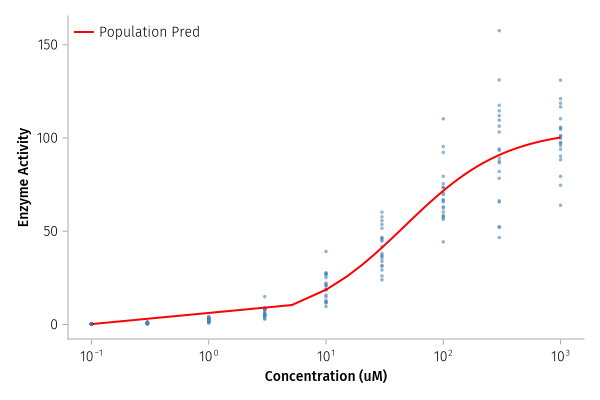

Figure 1: Problem 1: Michaelis-Menten Fit to Enzyme Kinetics Data

```julia
enz_coefs = coef(enz_fo)
conc_range = range(0.1, 1000, length = 200)
pred_act = enz_coefs.tvVMAX .* conc_range ./ (enz_coefs.tvKM .+ conc_range)

fig = Figure(size = (600, 400))
ax = Axis(fig[1, 1], xlabel = "Concentration (uM)", ylabel = "Enzyme Activity",
    xscale = log10)
scatter!(ax, enz_df.CONC, enz_df.dv, color = :steelblue, markersize = 5, alpha = 0.6)
lines!(ax, collect(conc_range), pred_act, color = :red, linewidth = 2, label = "Population Pred")
axislegend(ax, position = :lt)
fig
```

## 3.2 Problem 2: QTc Population Models

Population analysis of QTc exposure response data from Phase 1. Three models are compared:

1. **Naive pool (linear)** — no IIV, OMEGA BLOCK fixed at 0
2. **Population linear** — with IIV on intercept and slope
3. **Population Emax** — with IIV on E0, Emax, EC50

```julia
dqtc_raw = CSV.read(joinpath(data_dir, "dqtc.csv"), DataFrame)
rename!(dqtc_raw, "SID" => :id, "CONC" => :conc, "dqtc" => :dv)

# Monotonic time per subject (row index)
dqtc_raw.time = Vector{Float64}(undef, nrow(dqtc_raw))
for gdf in groupby(dqtc_raw, :id)
    gdf.time .= Float64.(1:nrow(gdf))
end

pop_dqtc = read_pumas(dqtc_raw; observations = [:dv], covariates = [:conc], event_data = false)
println("Subjects: ", length(pop_dqtc))
```

```
Subjects: 64
```

### 3.2.1 Model 1: Naive Pool Linear (no IIV)

Equivalent to NONMEM `$OMEGA BLOCK(2) 0 / 0 0 FIXED`:

```julia
qtc_naive = @model begin
    @param begin
        tvINT ∈ RealDomain(init = 1.0)
        tvSLP ∈ RealDomain(init = 0.02)
        σ_add ∈ RealDomain(lower = 0.0, init = 5.0)
    end
    @covariates conc
    @pre begin
        INT = tvINT
        SLP = tvSLP
    end
    @derived begin
        mu := @. INT + SLP * conc
        dv ~ @. Normal(mu, σ_add)
    end
end
```

```
PumasModel
  Parameters: tvINT, tvSLP, σ_add
  Random effects:
  Covariates: conc
  Dynamical system variables:
  Dynamical system type: No dynamical model
  Derived: dv
  Observed: dv
```

```julia
qtc_naive_fit = fit(qtc_naive, pop_dqtc,
    (tvINT = 1.0, tvSLP = 0.02, σ_add = 5.0),
    Pumas.NaivePooled())
qtc_naive_fit
```

```
[ Info: Checking the initial parameter values.
[ Info: The initial negative log likelihood and its gradient are finite. Check passed.
Iter     Function value   Gradient norm
     0     2.177739e+03     1.418514e+04
 * time: 5.793571472167969e-5
     1     2.145965e+03     6.258659e+02
 * time: 0.36159205436706543
     2     2.118681e+03     7.104756e+02
 * time: 0.3618330955505371
     3     1.915684e+03     2.055385e+03
 * time: 0.362030029296875
     4     1.856796e+03     2.183562e+03
 * time: 0.36221909523010254
     5     1.856667e+03     8.088581e+03
 * time: 0.362368106842041
     6     1.853771e+03     2.659683e+03
 * time: 0.36250805854797363
     7     1.851798e+03     1.320097e+03
 * time: 0.3626539707183838
     8     1.847591e+03     1.163686e+02
 * time: 0.3627970218658447
     9     1.814822e+03     6.855837e+03
 * time: 0.3629319667816162
    10     1.791657e+03     8.789379e+03
 * time: 0.3630690574645996
    11     1.785043e+03     3.339229e+03
 * time: 0.3632030487060547
    12     1.783504e+03     1.702782e+02
 * time: 0.3633451461791992
    13     1.783244e+03     1.914953e+02
 * time: 0.3634779453277588
    14     1.783242e+03     2.541537e+00
 * time: 0.3636140823364258
    15     1.783242e+03     1.408389e-01
 * time: 0.363753080368042
    16     1.783242e+03     3.340979e-03
 * time: 0.36388707160949707
    17     1.783242e+03     6.584688e-05
 * time: 0.3640329837799072
```

```
FittedPumasModel

Dynamical system type:          No dynamical model

Number of subjects:                             64

Observation records:         Active        Missing
    dv:                         812              0
    Total:                      812              0

Number of parameters:      Constant      Optimized
                                  0              3

Likelihood approximation:              NaivePooled
Likelihood optimizer:                         BFGS

Termination Reason:                   GradientNorm
Log-likelihood value:                   -1783.2424

------------------
        Estimate
------------------
tvINT   -0.088942
tvSLP    0.016926
σ_add    2.1753
------------------
```

### 3.2.2 Model 2: Population Linear (diagonal IIV)

```julia
qtc_pop_lin = @model begin
    @param begin
        tvINT ∈ RealDomain(init = 1.0)
        tvSLP ∈ RealDomain(init = 0.2)
        Ω     ∈ PDiagDomain(2)
        σ_add ∈ RealDomain(lower = 0.0, init = 3.16)
    end
    @random begin
        η ~ MvNormal(Ω)
    end
    @covariates conc
    @pre begin
        INT = tvINT + η[1]
        SLP = tvSLP + η[2]
    end
    @derived begin
        mu := @. INT + SLP * conc
        dv ~ @. Normal(mu, σ_add)
    end
end
```

```
PumasModel
  Parameters: tvINT, tvSLP, Ω, σ_add
  Random effects: η
  Covariates: conc
  Dynamical system variables:
  Dynamical system type: No dynamical model
  Derived: dv
  Observed: dv
```

```julia
qtc_pop_fit = fit(qtc_pop_lin, pop_dqtc,
    (tvINT = 1.0, tvSLP = 0.2, Ω = Diagonal([0.1, 0.2]), σ_add = sqrt(10.0)),
    Pumas.FOCE())
qtc_pop_fit
```

```
[ Info: Checking the initial parameter values.
[ Info: The initial negative log likelihood and its gradient are finite. Check passed.
Iter     Function value   Gradient norm
     0     1.946113e+03     5.631218e+02
 * time: 1.7881393432617188e-5
     1     1.725899e+03     4.212633e+02
 * time: 0.4035990238189697
     2     1.677271e+03     1.943342e+02
 * time: 0.40445590019226074
     3     1.650182e+03     6.334516e+01
 * time: 0.40516090393066406
     4     1.637005e+03     7.223578e+01
 * time: 0.40584707260131836
     5     1.632158e+03     4.568235e+01
 * time: 0.40653204917907715
     6     1.624934e+03     2.013463e+01
 * time: 0.40718603134155273
     7     1.623045e+03     2.024793e+01
 * time: 0.4078540802001953
     8     1.617261e+03     3.906291e+01
 * time: 0.4085230827331543
     9     1.606577e+03     1.060489e+02
 * time: 0.4092130661010742
    10     1.565896e+03     3.676768e+02
 * time: 0.4099729061126709
    11     1.543994e+03     2.209361e+02
 * time: 0.4116358757019043
    12     1.541115e+03     1.818206e+02
 * time: 0.4123380184173584
    13     1.536554e+03     1.049645e+02
 * time: 0.41300487518310547
    14     1.532072e+03     1.480411e+02
 * time: 0.4136829376220703
    15     1.522174e+03     5.041024e+01
 * time: 0.4145689010620117
    16     1.514611e+03     8.654016e+01
 * time: 0.41552090644836426
    17     1.512978e+03     9.238392e+01
 * time: 0.41629791259765625
    18     1.510279e+03     1.252041e+02
```

[output cut: 10 more lines]

```
 * time: 0.4484560489654541
    24     1.479730e+03     1.634952e+02
 * time: 0.4493720531463623
    25     1.479427e+03     1.382633e+02
 * time: 0.45003294944763184
    26     1.479392e+03     1.275796e+01
 * time: 0.4507009983062744
    27     1.479392e+03     7.709314e-01
 * time: 0.45136499404907227
    28     1.479392e+03     5.331967e-02
 * time: 0.4520750045776367
    29     1.479392e+03     6.878027e-03
 * time: 0.4527130126953125
    30     1.479392e+03     6.363288e-04
 * time: 0.45334696769714355
```

```
FittedPumasModel

Dynamical system type:          No dynamical model

Number of subjects:                             64

Observation records:         Active        Missing
    dv:                         812              0
    Total:                      812              0

Number of parameters:      Constant      Optimized
                                  0              5

Likelihood approximation:                     FOCE
Likelihood optimizer:                         BFGS

Termination Reason:                   GradientNorm
Log-likelihood value:                   -1479.3915

------------------
        Estimate
------------------
tvINT   0.15898
tvSLP   0.013788
Ω₁,₁    1.0842
Ω₂,₂    2.2605e-5
σ_add   1.3379
------------------
```

### 3.2.3 Model 3: Population Emax

```julia
qtc_emax = @model begin
    @param begin
        tvE0   ∈ RealDomain(init = 0.1)
        tvEmax ∈ RealDomain(init = 40.0)
        tvEC50 ∈ RealDomain(lower = 0.0, init = 1000.0)
        Ω      ∈ PSDDomain(3)
        σ_add  ∈ RealDomain(lower = 0.0, init = 3.16)
    end
    @random begin
        η ~ MvNormal(Ω)
    end
    @covariates conc
    @pre begin
        E0   = tvE0 + η[1]
        EC50 = tvEC50 * exp(η[2])
        Emax = tvEmax + η[3]
    end
    @derived begin
        mu := @. E0 + Emax * conc / (EC50 + conc)
        dv ~ @. Normal(mu, σ_add)
    end
end
```

```
PumasModel
  Parameters: tvE0, tvEmax, tvEC50, Ω, σ_add
  Random effects: η
  Covariates: conc
  Dynamical system variables:
  Dynamical system type: No dynamical model
  Derived: dv
  Observed: dv
```

```julia
qtc_emax_fit = fit(qtc_emax, pop_dqtc,
    (tvE0 = 0.1, tvEmax = 40.0, tvEC50 = 1000.0,
     Ω = [0.1 0.01 0.01; 0.01 0.1 0.01; 0.01 0.01 0.1],
     σ_add = sqrt(10.0)),
    Pumas.FOCE())
qtc_emax_fit
```

```
[ Info: Checking the initial parameter values.
[ Info: The initial negative log likelihood and its gradient are finite. Check passed.
Iter     Function value   Gradient norm
     0     1.871557e+03     5.256135e+02
 * time: 3.314018249511719e-5
     1     1.726619e+03     6.335882e+02
 * time: 0.3728041648864746
     2     1.632397e+03     2.206707e+02
 * time: 0.37501001358032227
     3     1.601012e+03     7.437475e+01
 * time: 0.37687206268310547
     4     1.590285e+03     4.988657e+01
 * time: 0.7839939594268799
     5     1.584782e+03     5.314367e+01
 * time: 0.7858569622039795
     6     1.570803e+03     2.829331e+01
 * time: 0.7875661849975586
     7     1.569767e+03     1.343165e+01
 * time: 0.7891290187835693
     8     1.567879e+03     3.358515e+01
 * time: 0.7907440662384033
     9     1.563679e+03     7.950324e+01
 * time: 0.7925851345062256
    10     1.558588e+03     1.150816e+02
 * time: 0.7945101261138916
    11     1.554793e+03     7.332243e+01
 * time: 0.7968120574951172
    12     1.550747e+03     1.623739e+01
 * time: 0.7988619804382324
    13     1.548074e+03     3.992431e+01
 * time: 0.801185131072998
    14     1.545245e+03     6.347403e+01
 * time: 0.8033521175384521
    15     1.538866e+03     8.631144e+01
 * time: 0.8057639598846436
    16     1.533309e+03     6.252670e+01
 * time: 0.80873703956604
    17     1.525244e+03     1.922217e+01
 * time: 0.8114571571350098
    18     1.520555e+03     3.148577e+01
```

[output cut: 70 more lines]

```
 * time: 0.9309720993041992
    54     1.453354e+03     1.990846e-01
 * time: 0.9329590797424316
    55     1.453353e+03     1.949871e-01
 * time: 0.9348721504211426
    56     1.453353e+03     9.176580e-02
 * time: 0.9365851879119873
    57     1.453353e+03     2.141122e-02
 * time: 0.9380781650543213
    58     1.453353e+03     5.188243e-03
 * time: 0.9446201324462891
    59     1.453353e+03     5.188243e-03
 * time: 0.9479260444641113
    60     1.453353e+03     5.188243e-03
 * time: 0.9514420032501221
```

```
FittedPumasModel

Dynamical system type:          No dynamical model

Number of subjects:                             64

Observation records:         Active        Missing
    dv:                         812              0
    Total:                      812              0

Number of parameters:      Constant      Optimized
                                  0             10

Likelihood approximation:                     FOCE
Likelihood optimizer:                         BFGS

Termination Reason:              NoObjectiveChange
Log-likelihood value:                   -1453.3531

---------------------
         Estimate
---------------------
tvE0       -0.038189
tvEmax     75.865
tvEC50   4092.9
Ω₁,₁        1.0971
Ω₂,₁        0.77456
Ω₃,₁       31.495
Ω₂,₂        0.54683
Ω₃,₂       22.235
Ω₃,₃     1499.0
σ_add       1.2882
---------------------
```

### 3.2.4 Model Comparison

```julia
println("Model Comparison (QTc)")
println("=" ^ 50)
println("Naive Linear  AIC: ", round(aic(qtc_naive_fit), digits = 1))
println("Pop Linear    AIC: ", round(aic(qtc_pop_fit), digits = 1))
println("Pop Emax      AIC: ", round(aic(qtc_emax_fit), digits = 1))
```

```
Model Comparison (QTc)
==================================================
Naive Linear  AIC: 3572.5
Pop Linear    AIC: 2968.8
Pop Emax      AIC: 2926.7
```

## 3.3 Problem 3: AST Emax Population Model

Population analysis of AST exposure response data from Phase 1.

```julia
ast_raw = CSV.read(joinpath(data_dir, "ast.csv"), DataFrame)
rename!(ast_raw, "SID" => :id, "CONC" => :conc, "AST" => :dv)

ast_raw.time = Vector{Float64}(undef, nrow(ast_raw))
for gdf in groupby(ast_raw, :id)
    gdf.time .= Float64.(1:nrow(gdf))
end

pop_ast = read_pumas(ast_raw; observations = [:dv], covariates = [:conc], event_data = false)
```

```
Population
  Subjects: 64
  Covariates: conc (heterogenous)
  Observations: dv (heterogenous)
```

```julia
ast_emax = @model begin
    @metadata begin
        desc = "AST Emax Population Model"
    end
    @param begin
        tvE0   ∈ RealDomain(init = 20.0)
        tvEC50 ∈ RealDomain(lower = 0.0, init = 100.0)
        tvEmax ∈ RealDomain(init = 50.0)
        Ω      ∈ PSDDomain(3)
        σ_add  ∈ RealDomain(lower = 0.0, init = 3.16)
    end
    @random begin
        η ~ MvNormal(Ω)
    end
    @covariates conc
    @pre begin
        E0   = tvE0 + η[1]
        EC50 = tvEC50 * exp(η[2])
        Emax = tvEmax + η[3]
    end
    @derived begin
        mu := @. E0 + Emax * conc / (EC50 + conc)
        dv ~ @. Normal(mu, σ_add)
    end
end
```

```
PumasModel
  Parameters: tvE0, tvEC50, tvEmax, Ω, σ_add
  Random effects: η
  Covariates: conc
  Dynamical system variables:
  Dynamical system type: No dynamical model
  Derived: dv
  Observed: dv
```

```julia
ast_fit = fit(ast_emax, pop_ast,
    (tvE0 = 20.0, tvEC50 = 100.0, tvEmax = 50.0,
     Ω = [0.1 0.01 0.01; 0.01 0.1 0.01; 0.01 0.01 0.1],
     σ_add = sqrt(10.0)),
    Pumas.FOCE())
ast_fit
```

```
[ Info: Checking the initial parameter values.
[ Info: The initial negative log likelihood and its gradient are finite. Check passed.
Iter     Function value   Gradient norm
     0     1.694226e+03     1.577918e+03
 * time: 2.193450927734375e-5
     1     9.191714e+02     9.604917e+01
 * time: 0.5070838928222656
     2     9.067138e+02     8.195403e+01
 * time: 0.5085499286651611
     3     8.858533e+02     5.126383e+01
 * time: 0.5097339153289795
     4     8.783999e+02     6.345648e+01
 * time: 0.5108730792999268
     5     8.671584e+02     8.291959e+01
 * time: 0.5119888782501221
     6     8.538607e+02     7.804764e+01
 * time: 0.5131618976593018
     7     8.429917e+02     4.142100e+01
 * time: 0.5144391059875488
     8     8.406836e+02     9.453546e+00
 * time: 0.5156209468841553
     9     8.405201e+02     9.658065e+00
 * time: 0.5166380405426025
    10     8.399121e+02     1.046413e+01
 * time: 0.5177910327911377
    11     8.394418e+02     1.642671e+01
 * time: 0.5189030170440674
    12     8.390421e+02     1.503612e+01
 * time: 0.5199248790740967
    13     8.381302e+02     1.089462e+01
 * time: 0.5209779739379883
    14     8.358632e+02     1.002887e+01
 * time: 0.5485200881958008
    15     8.323047e+02     1.806133e+01
 * time: 0.5498509407043457
    16     8.310067e+02     1.099528e+01
 * time: 0.5511000156402588
    17     8.307111e+02     9.698122e+00
 * time: 0.5521519184112549
    18     8.301625e+02     9.316964e+00
```

[output cut: 234 more lines]

```
 * time: 0.7618279457092285
   136     8.053475e+02     1.936667e-02
 * time: 0.7663478851318359
   137     8.053475e+02     4.619635e-03
 * time: 0.7673399448394775
   138     8.053474e+02     3.401024e-03
 * time: 0.7683470249176025
   139     8.053474e+02     5.460919e-03
 * time: 0.7692348957061768
   140     8.053474e+02     4.049276e-03
 * time: 0.7701120376586914
   141     8.053474e+02     1.227562e-03
 * time: 0.7709879875183105
   142     8.053474e+02     5.661175e-04
 * time: 0.7719039916992188
```

```
FittedPumasModel

Dynamical system type:          No dynamical model

Number of subjects:                             64

Observation records:         Active        Missing
    dv:                         235              0
    Total:                      235              0

Number of parameters:      Constant      Optimized
                                  0             10

Likelihood approximation:                     FOCE
Likelihood optimizer:                         BFGS

Termination Reason:                   GradientNorm
Log-likelihood value:                   -805.34742

-------------------
         Estimate
-------------------
tvE0       15.276
tvEC50    905.66
tvEmax     94.772
Ω₁,₁        9.6107
Ω₂,₁        4.3304
Ω₃,₁      106.66
Ω₂,₂        1.9512
Ω₃,₂       48.059
Ω₃,₃     1183.7
σ_add       6.6229
-------------------
```

```julia
ast_infer = infer(ast_fit)
ast_infer
```

```
[ Info: Calculating: variance-covariance matrix.
┌ Error: Failed.
└ @ Pumas ~/.julia/packages/Pumas/GZeMg/src/estimation/inference.jl:601
```

```
Asymptotic inference results

Dynamical system type:          No dynamical model

Number of subjects:                             64

Observation records:         Active        Missing
    dv:                         235              0
    Total:                      235              0

Number of parameters:      Constant      Optimized
                                  0             10

Likelihood approximation:                     FOCE
Likelihood optimizer:                         BFGS

Termination Reason:                   GradientNorm
Log-likelihood value:                   -805.34742

---------------------------------------
         Estimate    SE    95.0% C.I.
---------------------------------------
tvE0       15.276    NaN   [ NaN; NaN]
tvEC50    905.66     NaN   [ NaN; NaN]
tvEmax     94.772    NaN   [ NaN; NaN]
Ω₁,₁        9.6107   NaN   [ NaN; NaN]
Ω₂,₁        4.3304   NaN   [ NaN; NaN]
Ω₃,₁      106.66     NaN   [ NaN; NaN]
Ω₂,₂        1.9512   NaN   [ NaN; NaN]
Ω₃,₂       48.059    NaN   [ NaN; NaN]
Ω₃,₃     1183.7      NaN   [ NaN; NaN]
σ_add       6.6229   NaN   [ NaN; NaN]
---------------------------------------


Variance-covariance matrix could not be
evaluated. The random effects may be over-
parameterized. Check the coefficients for
variance estimates near zero.
```

```
[ Info: Calculating predictions.
[ Info: Calculating weighted residuals.
[ Info: Calculating empirical bayes.
[ Info: Evaluating dose control parameters.
[ Info: Evaluating individual parameters.
[ Info: Done.
```

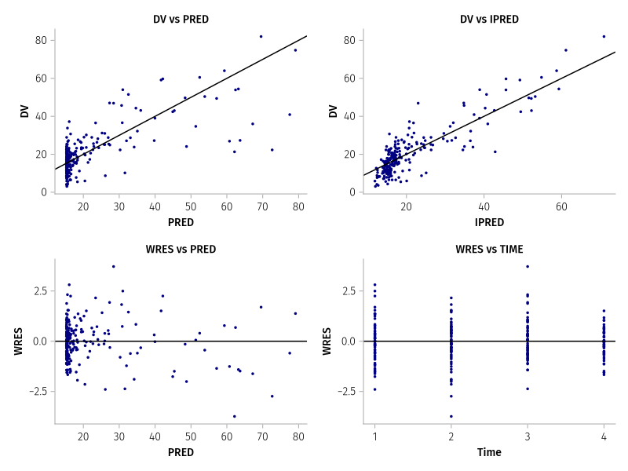

Figure 2: Problem 3: AST Emax GOF Diagnostics

```julia
ast_insp = inspect(ast_fit)
ast_insp_df = DataFrame(ast_insp)
obs_rows = @rsubset(ast_insp_df, !ismissing(:dv))

fig = Figure(size = (800, 600))

ax1 = Axis(fig[1, 1], xlabel = "PRED", ylabel = "DV", title = "DV vs PRED")
scatter!(ax1, obs_rows.dv_pred, obs_rows.dv, color = :navy, markersize = 5)
ablines!(ax1, 0, 1, color = :black)

ax2 = Axis(fig[1, 2], xlabel = "IPRED", ylabel = "DV", title = "DV vs IPRED")
scatter!(ax2, obs_rows.dv_ipred, obs_rows.dv, color = :navy, markersize = 5)
ablines!(ax2, 0, 1, color = :black)

ax3 = Axis(fig[2, 1], xlabel = "PRED", ylabel = "WRES", title = "WRES vs PRED")
scatter!(ax3, obs_rows.dv_pred, obs_rows.dv_wres, color = :navy, markersize = 5)
hlines!(ax3, 0, color = :black)

ax4 = Axis(fig[2, 2], xlabel = "Time", ylabel = "WRES", title = "WRES vs TIME")
scatter!(ax4, obs_rows.time, obs_rows.dv_wres, color = :navy, markersize = 5)
hlines!(ax4, 0, color = :black)

fig
```

## 3.4 Problem 4: Population PK (1-Compartment Oral)

Population PK analysis of a typical Phase 1 dataset. The data has known errors that must be fixed (as discovered in the R script).

```julia
pk_raw = CSV.read(joinpath(data_dir, "prob_2.csv"), DataFrame)
rename!(pk_raw,
    :ID => :id, :DV => :dv, :AMT => :amt,
    :II => :ii, :ADDL => :addl, :TIME => :time,
)

# Data cleaning (from R script: IndPopModels.Problem2.R)
# Fix 1: ID=13, AMT=20 should be 200
@rtransform!(pk_raw, :amt = (:id == 13 && :amt == 20) ? 200.0 : Float64(:amt))

# Fix 2: ID=22, II=6 should be 8
@rtransform!(pk_raw, :ii = (:id == 22 && :ii == 6) ? 8 : :ii)

# Fix 3: ID=2, dose TIME=24 should be 0
@rtransform!(pk_raw, :time = (:id == 2 && :amt > 0 && :time == 24) ? 0.0 : Float64(:time))

# Fix 4: ID=15, dose AMT=0 should be 200
@rtransform!(pk_raw, :amt = (:id == 15 && :time == 0 && :amt == 0) ? 200.0 : Float64(:amt))

# Drop comment column, add required columns
select!(pk_raw, Not(:C))
pk_raw.evid = ifelse.(pk_raw.amt .> 0, 1, 0)
pk_raw.cmt = ifelse.(pk_raw.amt .> 0, 1, 2)  # depot=1, central=2
pk_raw.dv = ifelse.(pk_raw.evid .== 1, missing, pk_raw.dv)

pop_pk = read_pumas(pk_raw)
println("Subjects: ", length(pop_pk))
```

```
Subjects: 25
```

```julia
# 1-cpt oral model: ADVAN2 TRANS2 equivalent
poppk_1cpt = @model begin
    @metadata begin
        desc = "1-Compartment Oral PopPK (ADVAN2 TRANS2)"
    end
    @param begin
        tvCL   ∈ RealDomain(lower = 0.0, init = 8.0)
        tvV    ∈ RealDomain(lower = 0.0, init = 50.0)
        tvKa   ∈ RealDomain(lower = 0.0, init = 0.45)
        Ω      ∈ PDiagDomain(3)
        σ_prop ∈ RealDomain(lower = 0.0, init = 0.2)
    end
    @random begin
        η ~ MvNormal(Ω)
    end
    @pre begin
        CL = tvCL * exp(η[1])
        Vc = tvV  * exp(η[2])
        Ka = tvKa * exp(η[3])
    end
    @dynamics Depots1Central1
    @derived begin
        cp := @. Central / Vc
        dv ~ @. Normal(cp, abs(cp) * σ_prop)
    end
end
```

```
PumasModel
  Parameters: tvCL, tvV, tvKa, Ω, σ_prop
  Random effects: η
  Covariates:
  Dynamical system variables: Depot, Central
  Dynamical system type: Closed form
  Derived: dv
  Observed: dv
```

```julia
pk_params = (
    tvCL = 8.0, tvV = 50.0, tvKa = 0.45,
    Ω = Diagonal([0.04, 0.04, 0.04]),
    σ_prop = 0.2,
)

# FO estimation first (matching NONMEM METHOD=0)
pk_fo = fit(poppk_1cpt, pop_pk, pk_params, Pumas.FO())
pk_fo
```

```
[ Info: Checking the initial parameter values.
[ Info: The initial negative log likelihood and its gradient are finite. Check passed.
Iter     Function value   Gradient norm
     0     8.264980e+01     2.753078e+01
 * time: 2.2172927856445312e-5
     1     8.141061e+01     5.944208e+01
 * time: 1.3636481761932373
     2     8.077844e+01     5.122005e+01
 * time: 1.364319086074829
     3     7.993858e+01     2.362374e+01
 * time: 1.364886999130249
     4     7.771907e+01     8.524163e+00
 * time: 1.3654201030731201
     5     7.744921e+01     5.509531e+00
 * time: 1.3659591674804688
     6     7.713191e+01     3.205463e+00
 * time: 1.3664031028747559
     7     7.703286e+01     2.240696e+00
 * time: 1.366866111755371
     8     7.698240e+01     3.473049e-01
 * time: 1.3673031330108643
     9     7.697257e+01     4.504869e-01
 * time: 1.3677361011505127
    10     7.695368e+01     6.067292e-01
 * time: 1.3681612014770508
    11     7.694136e+01     4.894391e-01
 * time: 1.3686342239379883
    12     7.692262e+01     4.692972e-01
 * time: 1.3691060543060303
    13     7.689627e+01     8.668093e-01
 * time: 1.3695740699768066
    14     7.686013e+01     1.080698e+00
 * time: 1.3700392246246338
    15     7.683395e+01     6.307220e-01
 * time: 1.370530128479004
    16     7.682714e+01     9.958439e-02
 * time: 1.3709781169891357
    17     7.682624e+01     8.441247e-02
 * time: 1.371408224105835
    18     7.682581e+01     1.294959e-01
 * time: 1.3718361854553223
    19     7.682555e+01     8.027178e-02
 * time: 1.3722660541534424
    20     7.682551e+01     2.023900e-02
 * time: 1.372709035873413
    21     7.682550e+01     3.212026e-03
 * time: 1.373138189315796
    22     7.682550e+01     2.372556e-04
 * time: 1.373603105545044
```

```
FittedPumasModel

Dynamical system type:                 Closed form

Number of subjects:                             25

Observation records:         Active        Missing
    dv:                         125              0
    Total:                      125              0

Number of parameters:      Constant      Optimized
                                  0              7

Likelihood approximation:                       FO
Likelihood optimizer:                         BFGS

Termination Reason:                   GradientNorm
Log-likelihood value:                   -76.825504

--------------------
         Estimate
--------------------
tvCL      8.0439
tvV      50.66
tvKa      0.49759
Ω₁,₁      0.058496
Ω₂,₂      0.057974
Ω₃,₃      0.0083115
σ_prop    0.15247
--------------------
```

```julia
# Re-fit with FOCEI for better estimates
pk_focei = fit(poppk_1cpt, pop_pk, pk_params, Pumas.FOCEI())
pk_focei
```

```
[ Info: Checking the initial parameter values.
[ Info: The initial negative log likelihood and its gradient are finite. Check passed.
Iter     Function value   Gradient norm
     0     7.571519e+01     3.057811e+01
 * time: 2.4080276489257812e-5
     1     7.272019e+01     2.670023e+01
 * time: 0.380601167678833
     2     7.044261e+01     1.658803e+01
 * time: 0.3841361999511719
     3     6.973885e+01     1.215980e+01
 * time: 0.3862471580505371
     4     6.956608e+01     5.783517e+00
 * time: 0.38887810707092285
     5     6.914330e+01     4.683046e+00
 * time: 0.39066410064697266
     6     6.892282e+01     1.076909e+00
 * time: 0.39240503311157227
     7     6.886545e+01     7.776024e-01
 * time: 0.3941681385040283
     8     6.879593e+01     7.129593e-01
 * time: 0.39599609375
     9     6.874807e+01     7.434706e-01
 * time: 0.3976931571960449
    10     6.863010e+01     1.021736e+00
 * time: 0.3994481563568115
    11     6.851866e+01     9.436458e-01
 * time: 0.4391801357269287
    12     6.841345e+01     9.920031e-01
 * time: 0.4410359859466553
    13     6.834219e+01     7.754581e-01
 * time: 0.4427511692047119
    14     6.827168e+01     7.149361e-01
 * time: 0.44454216957092285
    15     6.821152e+01     6.196741e-01
 * time: 0.44622302055358887
    16     6.818100e+01     2.081450e-01
 * time: 0.4478580951690674
    17     6.816906e+01     1.109124e-01
 * time: 0.4495580196380615
    18     6.816207e+01     1.665597e-01
```

[output cut: 8 more lines]

```
 * time: 0.4574730396270752
    23     6.814975e+01     3.439474e-02
 * time: 0.45899009704589844
    24     6.814946e+01     1.448103e-02
 * time: 0.46054911613464355
    25     6.814933e+01     4.476179e-03
 * time: 0.46212220191955566
    26     6.814927e+01     8.170391e-03
 * time: 0.46361804008483887
    27     6.814923e+01     7.013814e-03
 * time: 0.4652111530303955
    28     6.814921e+01     2.612858e-03
 * time: 0.46680712699890137
    29     6.814920e+01     9.269186e-04
 * time: 0.4684431552886963
```

```
FittedPumasModel

Dynamical system type:                 Closed form

Number of subjects:                             25

Observation records:         Active        Missing
    dv:                         125              0
    Total:                      125              0

Number of parameters:      Constant      Optimized
                                  0              7

Likelihood approximation:                     FOCE
Likelihood optimizer:                         BFGS

Termination Reason:                   GradientNorm
Log-likelihood value:                   -68.149202

--------------------
         Estimate
--------------------
tvCL      8.3055
tvV      45.422
tvKa      0.40781
Ω₁,₁      0.057279
Ω₂,₂      0.052748
Ω₃,₃      5.6956e-7
σ_prop    0.15245
--------------------
```

```julia
pk_infer = infer(pk_focei)
pk_infer
```

```
[ Info: Calculating: variance-covariance matrix.
┌ Error: Failed.
└ @ Pumas ~/.julia/packages/Pumas/GZeMg/src/estimation/inference.jl:601
```

```
Asymptotic inference results

Dynamical system type:                 Closed form

Number of subjects:                             25

Observation records:         Active        Missing
    dv:                         125              0
    Total:                      125              0

Number of parameters:      Constant      Optimized
                                  0              7

Likelihood approximation:                     FOCE
Likelihood optimizer:                         BFGS

Termination Reason:                   GradientNorm
Log-likelihood value:                   -68.149202

----------------------------------------
         Estimate     SE    95.0% C.I.
----------------------------------------
tvCL      8.3055      NaN   [ NaN; NaN]
tvV      45.422       NaN   [ NaN; NaN]
tvKa      0.40781     NaN   [ NaN; NaN]
Ω₁,₁      0.057279    NaN   [ NaN; NaN]
Ω₂,₂      0.052748    NaN   [ NaN; NaN]
Ω₃,₃      5.6956e-7   NaN   [ NaN; NaN]
σ_prop    0.15245     NaN   [ NaN; NaN]
----------------------------------------


Variance-covariance matrix could not be
evaluated. The random effects may be over-
parameterized. Check the coefficients for
variance estimates near zero.
```

```
[ Info: Calculating predictions.
[ Info: Calculating weighted residuals.
[ Info: Calculating empirical bayes.
[ Info: Evaluating dose control parameters.
[ Info: Evaluating individual parameters.
[ Info: Done.
```

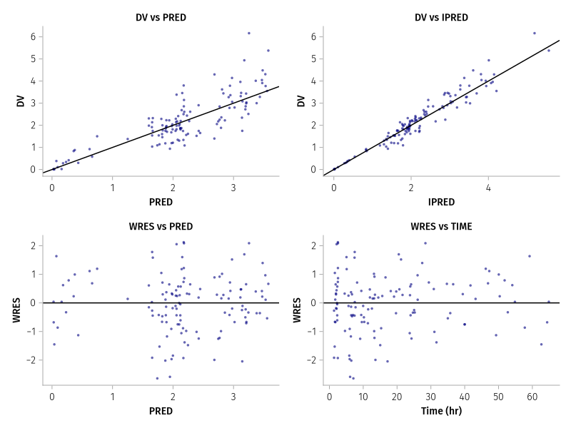

Figure 3: Problem 4: PopPK GOF Diagnostics

```julia
pk_insp = inspect(pk_focei)
pk_df = DataFrame(pk_insp)
pk_obs = @rsubset(pk_df, !ismissing(:dv))

fig = Figure(size = (800, 600))

ax1 = Axis(fig[1, 1], xlabel = "PRED", ylabel = "DV", title = "DV vs PRED")
scatter!(ax1, pk_obs.dv_pred, pk_obs.dv, color = :navy, markersize = 5, alpha = 0.6)
ablines!(ax1, 0, 1, color = :black)

ax2 = Axis(fig[1, 2], xlabel = "IPRED", ylabel = "DV", title = "DV vs IPRED")
scatter!(ax2, pk_obs.dv_ipred, pk_obs.dv, color = :navy, markersize = 5, alpha = 0.6)
ablines!(ax2, 0, 1, color = :black)

ax3 = Axis(fig[2, 1], xlabel = "PRED", ylabel = "WRES", title = "WRES vs PRED")
scatter!(ax3, pk_obs.dv_pred, pk_obs.dv_wres, color = :navy, markersize = 5, alpha = 0.6)
hlines!(ax3, 0, color = :black)

ax4 = Axis(fig[2, 2], xlabel = "Time (hr)", ylabel = "WRES", title = "WRES vs TIME")
scatter!(ax4, pk_obs.time, pk_obs.dv_wres, color = :navy, markersize = 5, alpha = 0.6)
hlines!(ax4, 0, color = :black)

fig
```

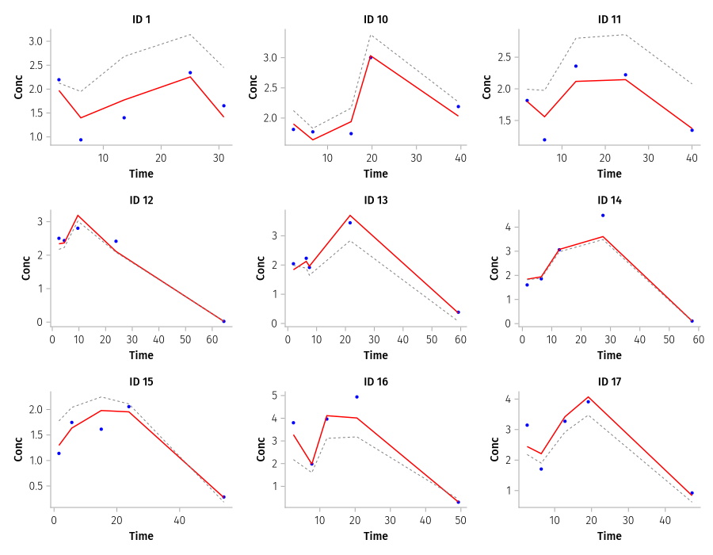

Figure 4: Problem 4: Individual Fits (first 9 subjects)

```julia
fig = Figure(size = (900, 700))
for (i, subj_id) in enumerate(unique(pk_obs.id)[1:9])
    row, col = divrem(i - 1, 3) .+ (1, 1)
    ax = Axis(fig[row, col], xlabel = "Time", ylabel = "Conc",
        title = "ID $subj_id")
    sdf = @rsubset(pk_obs, :id == subj_id)
    scatter!(ax, sdf.time, sdf.dv, color = :blue, markersize = 6)
    lines!(ax, sdf.time, sdf.dv_ipred, color = :red, linewidth = 1.5)
    lines!(ax, sdf.time, sdf.dv_pred, color = :gray, linewidth = 1, linestyle = :dash)
end
fig
```

**Comparing Pumas Objective Function to NONMEM**

When validating a Pumas model against NONMEM results:

- **NONMEM OFV (with constant)** = `-2 * loglikelihood(fit)` in Pumas — these should match exactly
- **NONMEM OFV (without constant)** = `-2 * loglikelihood(fit) - N * log(2π)` where `N` = total observations
- To compute the traditional OFV: `ofv = -2 * loglikelihood(fit) - nobs(fit) * log(2π)`

Common reasons for mismatch:

1. **Data differences** — column mapping, missing value handling, or filtering
2. **Parameterization** — different IIV or error model form
3. **Covariate interpolation** — NONMEM defaults to NOCB; Pumas defaults to LOCF (`covariates_direction = :left`)
4. **Initial estimates** — compare EBEs via `empirical_bayes(fit)` against NONMEM’s `.phi` file

**Pumas Error Model Convenience Functions**

Pumas provides named error distributions that simplify `@derived` blocks:

| Error Model | Manual Form | Convenience Form |
| --- | --- | --- |
| Additive | `dv ~ Normal(cp, σ_add)` | `dv ~ Normal(cp, σ_add)` |
| Proportional | `dv ~ Normal(cp, abs(cp) * σ_prop)` | `dv ~ ProportionalNormal(cp, σ_prop)` |
| Combined | `dv ~ Normal(cp, √(σ_add² + (cp*σ_prop)²))` | `dv ~ CombinedNormal(cp, σ_add, σ_prop)` |

`ProportionalNormal` and `CombinedNormal` handle the abs/sqrt internally.

**Connecting Error Models to Bioanalytical Assay Characteristics**

The choice of residual error model should be informed by the characteristics of the **bioanalytical assay**, not solely by statistical fit. **Additive error** implies constant measurement uncertainty across the concentration range, which is typical of assays operating near the **lower limit of quantification (LLOQ)** where absolute noise dominates. **Proportional error** implies uncertainty that scales with concentration, reflecting the behavior of most validated bioanalytical assays where the **coefficient of variation (%CV) is approximately constant** across the calibration range. **Combined error** captures both regimes simultaneously — additive noise dominates at low concentrations and proportional noise dominates at higher concentrations. In practice, the combined model is often the most realistic because assay precision degrades near the LLOQ (additive component) while maintaining a roughly constant %CV at mid-to-high concentrations (proportional component). Understanding the assay’s validated range and precision profile provides a principled basis for selecting the error model prior to estimation.

# 4 Study Guide Questions

1. Explain how you might interpret the standard error of the estimates.
2. List three things that you should look for in the Monitoring of Search output (optimizer convergence in Pumas).
3. List three diagnostic plots that you should create for a population NLME model.
4. How can you make sense of the off-diagonal elements of a covariance matrix?
5. Provide an initial estimate for the first element of OMEGA, assuming a proportional inter-individual %CV equal to 30%. (*Answer: 0.09, since for exponential IIV, omega = (CV/100)^2 = 0.3^2 = 0.09*)
6. Provide an initial estimate for SIGMA, assuming a constant residual error with standard deviation equal to 5. (*Answer: In NONMEM sigma=25 (variance); in Pumas sigma_add=5 (SD)*)

# 5 Supplementary Material

[output not shown]